# Differences among propositions

Pierce Edmiston

2016-02-14

```r
# devtools::install_github("property-verification", "lupyanlab", subdir = "propertyverificationdata")
library(propertyverificationdata)
data(norms_responses) # raw responses given in the norming study
data(norms)           # responses summarized by proposition
data(question_first)  # experiment data
```

# Ambiguous propositions

Ideally, people would agree as to the truth or falseness of each of the 536 propositions we created for this experiment, yet against our best intentions, there were some propositions for which people did not agree on an answer.

To determine which propositions were ambiguous, I fit a linear model to the responses for each proposition given in the norming study. In the norming study, participants were asked to respond to the yes or no question on a 5-point scale from *Definitely no* to *Definitely yes*. The scale was centered on *Maybe*, corresponding to a truth value of 0. The linear models predicted mean truth value for each proposition, and the statistical test of interest was whether this value differently reliably from 0 (the intercept term), which would indicate that people tended to agree on the truth or falseness of each of the propositions.

Any proposition for which mean truth value did not significantly differ from 0 (*p* < 0.05) was deemed “ambiguous”. If the truth value of the proposition is ambiguous as determined by the norming participants, then supposedly incorrect responses to these propositions in the main experiment cannot be interpreted as errors in the actual experiment.

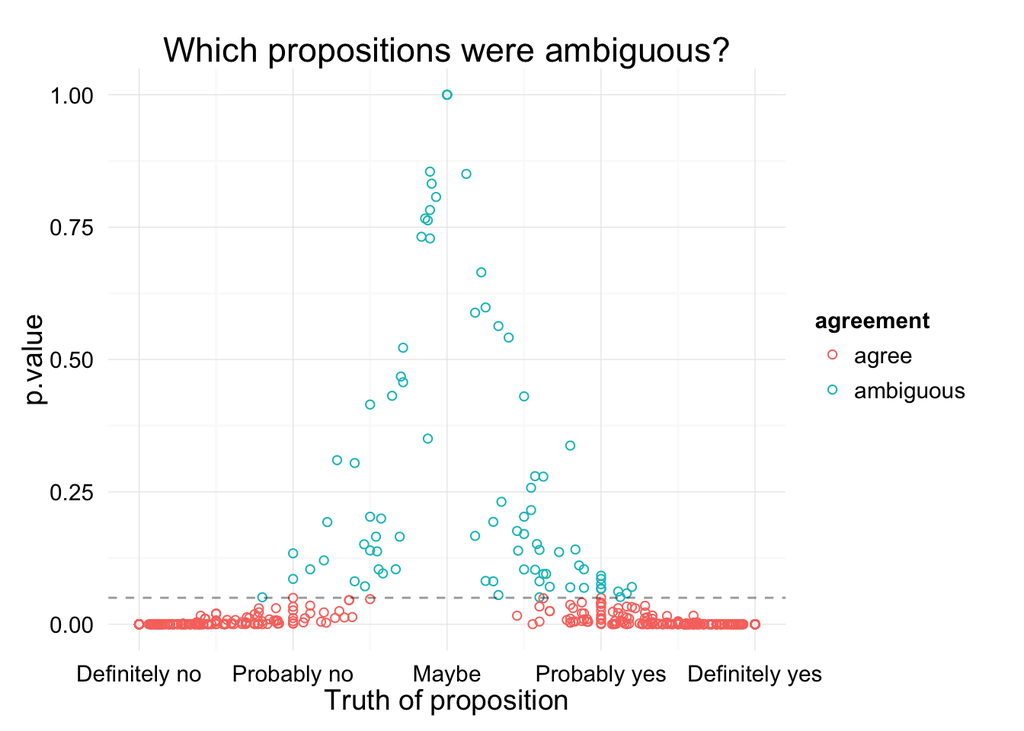

# Incorrectly-coded propositions

With the agreement scores above, we can also check whether the correct response as coded in the experiment matches what the norming participants thought was the correct answer. Basically, if there are any cases that the correct response was not the same as the norm truth value, we would conclude that these propositions were miscoded.

Fortunately of the questions that were not ambiguous, all of the questions were correctly coded.

```
## , , agreement = agree
##
##                 norm_response
## correct_response  no yes <NA>
##              no  226   0    0
##              yes   0 224    0
##
## , , agreement = ambiguous
##
##                 norm_response
## correct_response  no yes <NA>
##              no    0   0   36
##              yes   0   0   48
##
## , , agreement = NA
##
##                 norm_response
## correct_response  no yes <NA>
##              no    0   0    1
##              yes   0   0    1
```

# Proposition difficulty

To determine which propositions were too difficult, I fit a model predicting error rate on the nomask trials for each proposition. Presumably, college undergraduates should be able to to answer these questions correctly without any distractions, and therefore we would expect most of the propositions to have a reliably negative intercept term. A negative log-odds value when error rate is being predicted is interpreted as the question being easy to answer: errors were rare.

A positive log-odds value for the estimate indicates that errors were more likely than would be expected. More conservatively, a log-odds value that was *not* significantly negative is used as an indicator that the proposition was simply too difficult because too many people were getting it wrong.

The plot below is of the significance value of the intercept terms for each of these models. Propositions with positive estimates, or estimates that were not significantly different from chance, were labeled as being too hard.

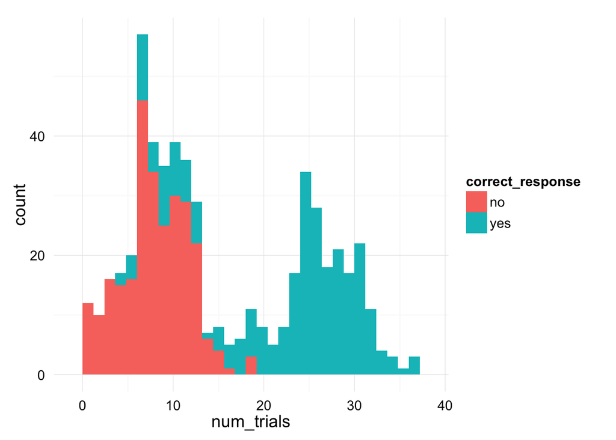

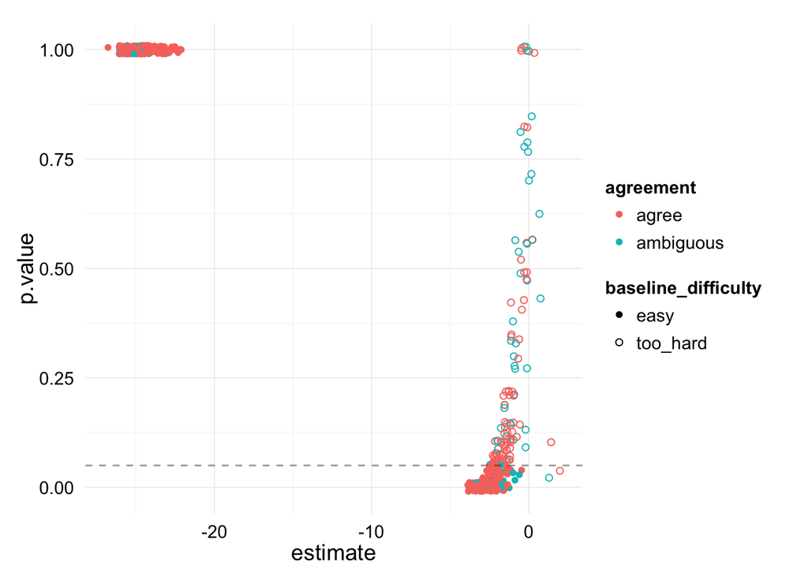

# Subjective and objective measures of proposition difficulty

Subjective proposition difficulty is measured as the mean difficulty rating given to the proposition by participants in the norming study.

Objective proposition difficulty is measured as mean performance on the proposition (error rate and reaction time) in the experiment **on the no mask trials only**.

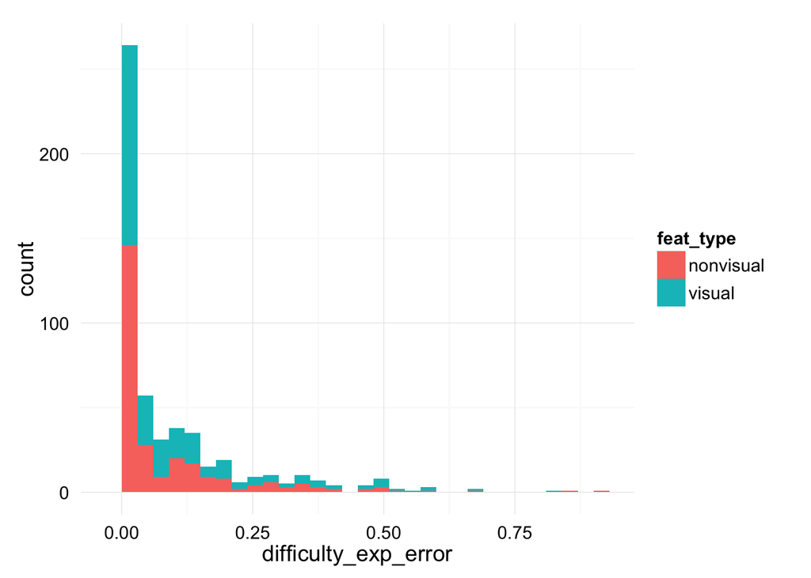

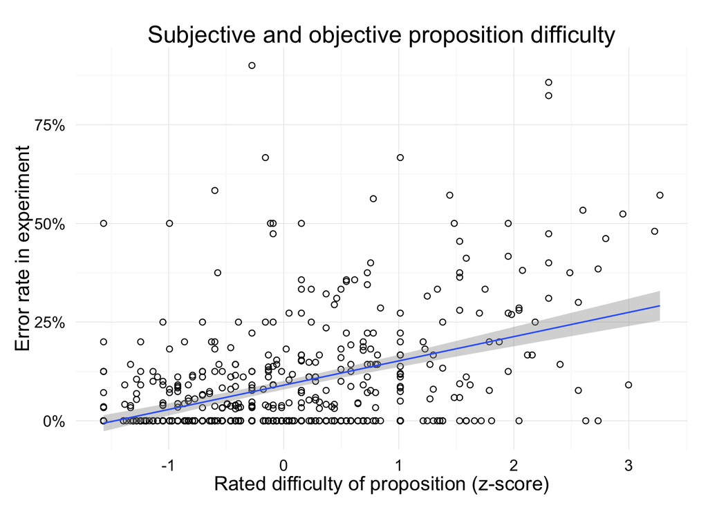

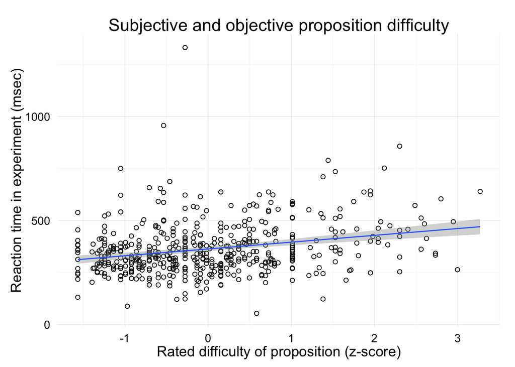

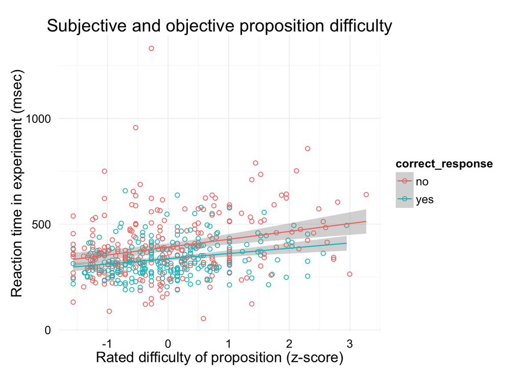

# Subsetting balanced propositions

```
## number of remaining propositions
```

```
## [1] 378
```

```
## distribution of propositions by type
```

```
##            correct_response
## feat_type    no yes
##   nonvisual  86 111
##   visual     82  99
```

```
## found one! 15
```

```
##            correct_response
## feat_type   no yes
##   nonvisual 50  50
##   visual    50  50
```

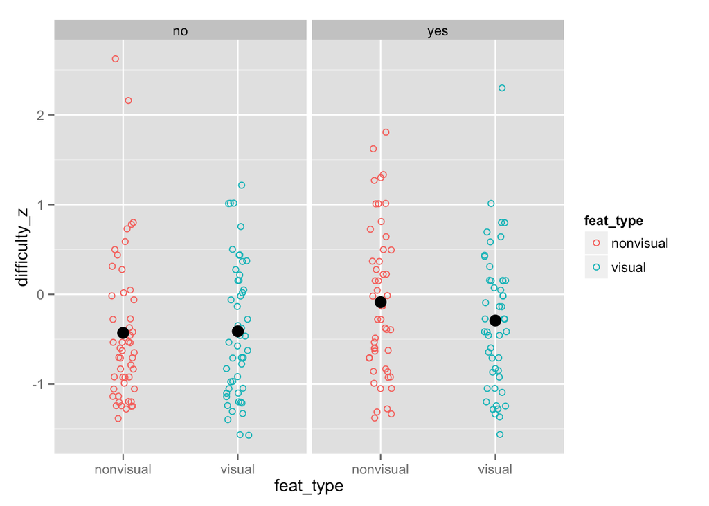

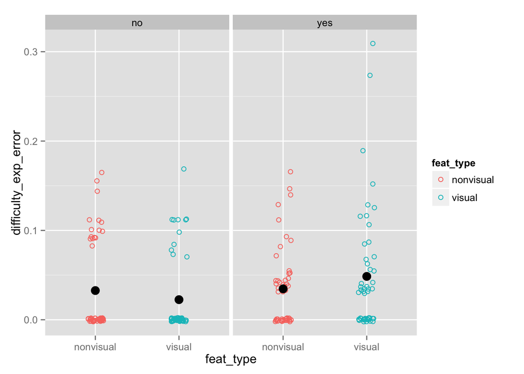

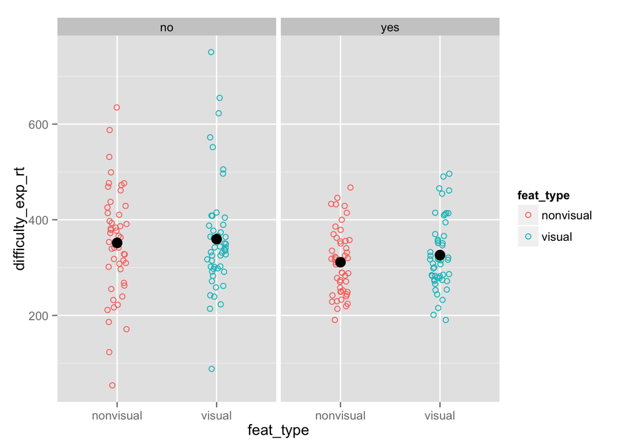